# Reference cell atlas for decidua and villi

Arun Chavan

Started: 2020-08-31  
Last edited: 2021-01-24 12:07:14

```r
### packages
library(tidyverse)
library(scater)
```

# 1 Background

The goal here is to create a reference set of celltype-specific transcriptomes for cell types present at the human fetal-maternal interface. Ideally we want bulk-representations of transcriptomes for all cell types. We can compare (by calculating correlation coefficients, e.g.) these to the averaged trancriptomes for each cluster from our data. The cell type to which a cluster has the highest similarity, is likely the cell type represented by that cluster. We can subsequently manually verify each of these assignments.

We can use data from previous single cell RNA-seq studies to do this. There are three studies that we can use.

1. (Pavličev et al. 2017): This is scRNA-seq of the villi at term. Appended to the villi data are also bulk transcriptomes of endometrial stormal fibroblasts (ESF) and decidual stromal cells (DSC) from primary cultures. Since this is an old fluidigm-based study, the number of cells is smaller compared to 10x.
2. (Vento-Tormo et al. 2018): This is scRNA-seq of fetal-maternal interface in the first trimester.
3. (Suryawanshi et al. 2018): This is also scRNA-seq of fetal-maternal interface in the first trimester.

Of these studies, (Pavličev et al. 2017) is the only dataset from term samples. Even though our data are from term samples, it would be worth it to compare them to the first-trimester data from (Vento-Tormo et al. 2018) and (Suryawanshi et al. 2018). There are many cell types at the fetal-maternal interface that don’t change through pregnancy—they can be easily cross-mapped even with the first-trimester data. Even for cell types that do change, we could use this comparison to narrow down their identities.

# 2 Get data in shape

The data from all three studies are in different formats, use different gene names etc. We need to first get them all in shape and make them comparable.

## 2.1 Vento-Tormo et al

The raw feature by barcode counts matrix from the 10x runs (`raw_data_10x.txt`) were downloaded from ArrayExpress accession [E-MTAB-6701](https://www.ebi.ac.uk/arrayexpress/experiments/E-MTAB-6701/files/). The associated metadata file `meta_10x.txt` contains cell metadata including cluster ids and cell type annotations.

We want to (1) read these data, (2) sum counts for all cell with the same cell type annotation, and (3) normalize counts to counts per million (cpm). This gives us bulk-representation of the transcriptomes for all annotated cell types.

### 2.1.1 Data

```r
### read data
vento.meta <- read.table("../ext/from-papers/vento-tormo_2018/10x_arrayexpress/meta_10x.txt", header = TRUE, sep = "\t")
vento.raw <- readSparseCounts("../ext/from-papers/vento-tormo_2018/10x_arrayexpress/raw_data_10x.txt", sep = "\t", row.names = TRUE, col.names = TRUE, chunk = 100)  # have to use readSparseCounts because the file is too big.
```

The counts matrix is for 64734 cells.

```r
dim(vento.raw)
```

```
[1] 31764 64734
```

```r
head(vento.raw[, 1:2])   # first five few rows and columns
```

```
6 x 2 sparse Matrix of class "dgCMatrix"
                         FCA7167222_TCTGGAACAGAGTGTG FCA7167226_GGAACTTGTCTAAACC
TNMD_ENSG00000000005                               .                           .
DPM1_ENSG00000000419                               3                           .
SCYL3_ENSG00000000457                              .                           .
C1orf112_ENSG00000000460                           .                           .
FGR_ENSG00000000938                                .                           .
CFH_ENSG00000000971                                2                           .
```

The metadata looks like this:

```r
head(vento.meta, 10)  # cell metadata
```

|  | Fetus | location | final_cluster | annotation |
| --- | --- | --- | --- | --- |
| FCA7167219_AAACGGGAGCTAGTTC | D6 | Decidua | 2 | dNK2 |
| FCA7167219_AAACGGGCATTGGCGC | D6 | Decidua | 5 | dNK1 |
| FCA7167219_AAACGGGTCGCGATCG | D6 | Decidua | 8 | Tcells |
| FCA7167219_AAAGATGAGCAATATG | D6 | Decidua | 10 | Tcells |
| FCA7167219_AAAGATGAGTTCGCGC | D6 | Decidua | 5 | dNK1 |
| FCA7167219_AAAGATGCATGTCGAT | D6 | Decidua | 8 | Tcells |
| FCA7167219_AAAGATGGTCTCGTTC | D6 | Decidua | 11 | dNK3 |
| FCA7167219_AAATGCCTCCCTTGCA | D6 | Decidua | 2 | dNK2 |
| FCA7167219_AACCATGCAGCAGTTT | D6 | Decidua | 5 | dNK1 |
| FCA7167219_AACCGCGCATAGGATA | D6 | Decidua | 11 | dNK3 |

According to the metadata file, there are 38 clusters.

```r
vento.meta$final_cluster %>% unique() %>% sort() # final clusters
```

```
 [1]  0  1  2  3  4  5  6  7  8  9 10 11 12 13 15 16 17 18 20 21 22 23 24 26 27 28 29 30 31 32 33 41 42 43 44 45 49 50
```

```r
vento.meta$annotation %>% unique() %>% sort() %>% cat(sep = ", ") # annotations
```

```
DC1, DC2, dM1, dM2, dM3, dNK p, dNK1, dNK2, dNK3, dP1, dP2, dS1, dS2, dS3, Endo (f), Endo (m), Endo L, Epi1, Epi2, EVT, fFB1, fFB2, Granulocytes, HB, ILC3, MO, NK CD16-, NK CD16+, Plasma, SCT, Tcells, VCT
```

### 2.1.2 Convert into a `SingleCellExperiment` object

```r
### create SingleCellExperiment object ----------------------------------------
vento.sce <- SingleCellExperiment(assays = list(counts = vento.raw))

### add colData ---------------------------------------------------------------
colData(vento.sce)$location <- vento.meta$location[match(rownames(colData(vento.sce)),
                                                         table = rownames(vento.meta)
                                                         )] # anatomical location
colData(vento.sce)$celltype <- vento.meta$annotation[match(rownames(colData(vento.sce)),
                                                           table = rownames(vento.meta)
                                                           )] # cell type annotations

### rowData -------------------------------------------------------------------
# extract ensembl id from rownames
rowData(vento.sce)$ID <- gsub(pattern  = "(.+)(_)(ENSG\\d+)",
                              replacement = "\\3",
                              rownames(rowData(vento.sce)))

# extract gene symbol from gene names
rowData(vento.sce)$Symbol <- gsub(pattern = "_ENSG\\d+",
                                  replacement = "",
                                  rownames(rowData(vento.sce)))
```

### 2.1.3 Aggregate data by cell type annotation

```r
# sum counts across barcodes by cell type annotation
vento.sum <- aggregateAcrossCells(vento.sce,
                                  ids = vento.sce$celltype,
                                  average = FALSE,
                                  use_exprs_values = "counts")

# summed library sizes
colSums(vento.sum@assays@data@listData$counts)
```

```
         DC1          DC2          dM1          dM2          dM3        dNK p         dNK1         dNK2         dNK3          dP1          dP2
     3225817      3820851     14637629     10419184     15150919      7366239     19042090     23579136      7871385      8121607      5715968
         dS1          dS2          dS3     Endo (f)     Endo (m)       Endo L         Epi1         Epi2          EVT         fFB1         fFB2
   103228762     58662666      7758508      1005854      6806365      2626996      1277126      1696038    121378497     20863029      1291455
Granulocytes           HB         ILC3           MO     NK CD16-     NK CD16+       Plasma          SCT       Tcells          VCT
     2907139     18935633       807321      4466950       913471      4216892      2179271     17833560     37307630    159712718
```

```r
# calculate cpm
assay(vento.sum, "cpm") <- calculateCPM(assay(vento.sum, "counts"))

# write cpm to data.frame
vento.cpm <- assay(vento.sum, "cpm") %>% as.data.frame()

# change column names to legal characters and add `vento` suffix
names(vento.cpm)[names(vento.cpm) == "dNK p"] <- "dNK.p"
names(vento.cpm)[names(vento.cpm) == "Endo (f)"] <- "Endo.f"
names(vento.cpm)[names(vento.cpm) == "Endo (m)"] <- "Endo.m"
names(vento.cpm)[names(vento.cpm) == "Endo L"] <- "Endo.L"
names(vento.cpm)[names(vento.cpm) == "NK CD16-"] <- "NK.CD16neg"
names(vento.cpm)[names(vento.cpm) == "NK CD16+"] <- "NK.CD16pos"

names(vento.cpm) <- paste0("vento_", names(vento.cpm))

# add gene names column
vento.cpm$gene_name <- gsub("_ENSG\\d+", "", rownames(vento.cpm))
vento.cpm <- vento.cpm %>% relocate(gene_name) # make it the first column

# remove rows that have duplicated gene names
dupgenes <- table(vento.cpm$gene_name) %>% as.data.frame() %>% filter(Freq > 1)
vento.cpm <- vento.cpm[!(vento.cpm$gene_name %in% dupgenes$Var1), ]
rownames(vento.cpm) <- NULL

# write
write.csv(vento.cpm, file = "../results/01_reference-atlas/vento-tormo_cpm-by-celltype.csv", row.names = FALSE)

# remove full dataset
rm(vento.raw)
rm(vento.sce)
```

## 2.2 Suryawanshi et al

(Suryawanshi et al. 2018) have provided TP10K normalized, averaged by cell type, data in the supplementary materials. So we don’t have to do that ourselves. The data for villous and decidual cell types are in two separate sheets in the excel file `aau4788_Data_file_S1.xlsx`. We just have to read the two sheets, combine them, and add `surya` prefix to all samples, so that we can differentiate them from `vento` and `pvali` samples when we analyse them all together.

### 2.2.1 Data

```r
### read data
surya.dec <- readxl::read_excel("../ext/from-papers/suryawanshi_2018/supp-data/aau4788_Data_file_S1.xlsx", sheet = "Decidua_averages_TPM10K", col_names = TRUE, range = "A1:N16968", trim_ws = TRUE)
surya.vil <- readxl::read_excel("../ext/from-papers/suryawanshi_2018/supp-data/aau4788_Data_file_S1.xlsx", sheet = "Villi_averages_TPM10K", col_names = TRUE, range = "A1:J17107", trim_ws = TRUE)

### prefixes
names(surya.dec)[names(surya.dec) != "Gene"] <- paste0("surya_dec.",
                                                       names(surya.dec)[names(surya.dec) != "Gene"])
names(surya.vil)[names(surya.vil) != "Gene"] <- paste0("surya_vil.",
                                                       names(surya.vil)[names(surya.vil) != "Gene"])

### merge
surya.tp10k <- dplyr::inner_join(surya.dec, surya.vil, by = "Gene")
```

```r
### fix gene names
# change column name
names(surya.tp10k)[names(surya.tp10k) == "Gene"] <- "gene_name"

# duplicates
table(surya.tp10k$gene_name) %>% as.data.frame() %>% filter(Freq > 1)
```

| Var1 | Freq |
| --- | --- |

No need to remove duplicated gene names since there are none.

```r
surya.tp10k %>% head()
```

| gene_name | surya_dec.DSC | surya_dec.LEC | surya_dec.VEC | surya_dec.EEC | surya_dec.NK1 | surya_dec.NK2 | surya_dec.TC | surya_dec.SMC | surya_dec.FB1 | surya_dec.FB2 | surya_dec.MAC | surya_dec.DC1 | surya_dec.DC2 | surya_vil.VCT | surya_vil.SCT | surya_vil.EVT | surya_vil.HC | surya_vil.EB | surya_vil.FB1 | surya_vil.FB2 | surya_vil.FB3 | surya_vil.VEC |
| --- | --- | --- | --- | --- | --- | --- | --- | --- | --- | --- | --- | --- | --- | --- | --- | --- | --- | --- | --- | --- | --- | --- |
| A1BG | 0.93718214 | 0.29518869 | 0.25173910 | 0.04065127 | 0.29627650 | 0.20097506 | 0.58278654 | 0.97359649 | 0.73504984 | 0.57964253 | 0.33616038 | 0.2721829 | 0.61046707 | 0.016405676 | 0.045273780 | 0.13305817 | 0.020167444 | 0.005987067 | 0.645928138 | 0.47164206 | 0.26468233 | 0.04608876 |
| A1BG-AS1 | 0.15284007 | 0.08050601 | 0.04195652 | 0.00000000 | 0.01742803 | 0.03349584 | 0.03428156 | 0.21165141 | 0.10943158 | 0.10249776 | 0.05932242 | 0.0000000 | 0.06104671 | 0.009650398 | 0.000000000 | 0.05322327 | 0.003361241 | 0.000000000 | 0.148245802 | 0.10635066 | 0.06352376 | 0.00000000 |
| A2M | 0.62202354 | 4.15947703 | 30.85901771 | 0.08943278 | 0.12199621 | 0.66991688 | 0.17140781 | 4.48700989 | 0.92294179 | 0.63972743 | 10.14413370 | 0.2041372 | 3.78489582 | 0.010615438 | 0.009054756 | 0.05322327 | 2.436899430 | 0.005987067 | 0.041473528 | 0.94328412 | 0.11116658 | 2.94391977 |
| A2M-AS1 | 0.00355442 | 0.00000000 | 0.12586955 | 0.00000000 | 0.00000000 | 0.01674792 | 0.10284468 | 0.02116514 | 0.02064747 | 0.01413762 | 0.01977414 | 0.0000000 | 0.00000000 | 0.003860159 | 0.000000000 | 0.00000000 | 0.010083722 | 0.000000000 | 0.001764831 | 0.00000000 | 0.00000000 | 0.00000000 |
| A4GALT | 0.08886051 | 0.40253004 | 0.37760865 | 0.12195380 | 0.20332701 | 0.10048753 | 0.00000000 | 0.42330282 | 0.16517974 | 0.10603217 | 0.00000000 | 0.0000000 | 0.00000000 | 0.165986844 | 0.018109512 | 0.11975235 | 0.003361241 | 0.003991378 | 0.073240486 | 0.01387183 | 0.08469834 | 0.05761095 |
| AAAS | 0.21563483 | 0.13417668 | 0.29369561 | 0.21138658 | 0.19751767 | 0.50243766 | 0.30853405 | 0.38097254 | 0.27048182 | 0.19085791 | 0.17796726 | 0.2721829 | 0.24418683 | 0.602184831 | 0.298806945 | 0.41248032 | 0.225203120 | 0.139698224 | 0.338847548 | 0.55949695 | 0.25409503 | 0.33414354 |

There are 22 cell types:

```r
names(surya.tp10k)[-1] %>% cat(sep = ", ")
```

```
surya_dec.DSC, surya_dec.LEC, surya_dec.VEC, surya_dec.EEC, surya_dec.NK1, surya_dec.NK2, surya_dec.TC, surya_dec.SMC, surya_dec.FB1, surya_dec.FB2, surya_dec.MAC, surya_dec.DC1, surya_dec.DC2, surya_vil.VCT, surya_vil.SCT, surya_vil.EVT, surya_vil.HC, surya_vil.EB, surya_vil.FB1, surya_vil.FB2, sur…
```

```r
write.csv(surya.tp10k, "../results/01_reference-atlas/surya_tp10k-by-celltype.csv", row.names = FALSE)
```

## 2.3 Pavlicev et al

The raw data are available on NCBI GEO, but I have transcriptomes averaged by cell type since I was involved in this study. We will just use those.

### 2.3.1 Data

This file was written on a different operating system, so the end of line characters are strange. When you try to read it with `read.table` with `col.names = TRUE` you get `more columns than column names` error. But it works fine if you don’t set `col.names = TRUE`. But then the auto-generated column names get added and the actual colnames become the first row. You have to fix that manually as below.

```r
### read data
pavli.tpm <- read.table("../ext/from-papers/pavlicev_2017/data/SC-ESC-SYN.txt", sep = "\t")

### column names
# fix the colnames = TRUE issue
names(pavli.tpm) <- pavli.tpm[1, ]
pavli.tpm <- pavli.tpm[-1, ]
pavli.tpm[, 2:9] <- lapply(pavli.tpm[, 2:9], as.numeric)

# rename gene names column
names(pavli.tpm)[names(pavli.tpm) == "geneID"] <- "gene_name"

# prefixes
names(pavli.tpm)[names(pavli.tpm) != "gene_name"] <- paste0("pavli_", names(pavli.tpm)[names(pavli.tpm) != "gene_name"])
```

```r
### duplicated gene names
table(pavli.tpm$gene_name) %>% as.data.frame() %>% filter(Freq > 1)
```

| Var1 | Freq |
| --- | --- |

There are no duplicated rows.

There are 8 cell types here:

```r
names(pavli.tpm)[names(pavli.tpm) != "gene_name"]  %>% cat(sep = ", ")
```

```
pavli_CYT1, pavli_CYT2, pavli_CYT3, pavli_DEND, pavli_EVT, pavli_SYN, pavli_DEC, pavli_ESF
```

```r
# write
write.csv(pavli.tpm, "../results/01_reference-atlas/pavli_tpm-by-celltype.csv", row.names = FALSE)
```

# 3 Merge datasets

These three datasets are from different sources, were generated using different technologies, and were processed using different methods. There are certainly batch effects and it’s not appropriate the expression values directly amongst them. But, we might be able to calculate correlations between celltypes in all three datasets as long as we use non-parametric correlation. For that we have `inner_join` these datasets to the intersection of genes shared in them.

```r
# join
vsp <- vento.cpm %>%
  inner_join(surya.tp10k, by = "gene_name") %>%
  inner_join(pavli.tpm, by = "gene_name")

# write
write.csv(vsp, "../results/01_reference-atlas/vento-surya-pavli_joined.csv", row.names = FALSE)
```

# 4 Compare datasets

We can measure spearman correlations between all pair of cell types from all three datasets. This would be useful for two reasons: (1) sanity check to make sure that corresponding cell types between datasets have the highest similarity, (2) if this works, it is likely that comparison of these datasets with our data would give us meaningful cell type annotations.

Steps:

1. Measure spearman correlation between all pairs of celltypes from all datasets.
2. Perform clustering using `1 - correlation` as distance, so that we can reorder the rows and columns by clustering pattern when plotting heatmaps.
3. Subset the correlation matrix to the desired pair of datasets, `query` and `reference`. (e.g. vento vs. surya)
4. Find top 3 celltypes in `reference` that have the highest correlation coefficient with each celltype in `query`.
5. Plot the heatmap of correlation matrix, indicating the top 3 most similar celltypes.

```r
# function for plotting correlation between celltypes from two datasets
celltypeCorPlot <- function(expdat, reference, query, ...) {

  ## build correlation matrix from expression data
  cor.matrix <- cor(expdat[, names(expdat)[names(expdat) != "gene_name"]],
                    method = 'spearman')

  ## reorder correlation matrix based on clustering
  dd <- as.dist((1 - cor.matrix)) # Use correlation between variables as distance
  hc <- hclust(dd, method = 'complete')
  cormat <- cor.matrix[hc$order, hc$order]

  ## melt correlation matrix
  dat <- reshape2::melt(cormat, na.rm = T)
  dat$Var1_source <- sapply(strsplit(as.character(dat$Var1), split = "_"), "[[", 1)
  dat$Var2_source <- sapply(strsplit(as.character(dat$Var2), split = "_"), "[[", 1)

  ## subset to the datasets you want to plot
  dat <- dat[which(dat$Var1_source %in% c(reference) &
                     dat$Var2_source %in% c(query)), ]

  ## max correlation coefficients
  # mark top3 celltypes from Var1 for each celltype in Var2.
  dat$top3 <- NA
  for(i in unique(dat$Var2)){
    ind <- which(dat$Var2 == i & dat$Var1_source != strsplit(i, "_")[[1]][1])
    val <- dat$value[ind]
    top3ind <- ind[order(val, decreasing = TRUE)[1:3]]
    dat$top3[top3ind[1]] <- "1"
    dat$top3[top3ind[2]] <- "2"
    dat$top3[top3ind[3]] <- "3"
  }

  ## plot
  p <- ggplot(data = dat,
              aes(Var1, Var2, fill = value)) +
    geom_tile(colour = "white") +
    scale_fill_gradient(low = 'white', high = 'red',
                        name = "Spearman\nCorrelation") +
    geom_point(aes(Var1, Var2, alpha = top3),
               size = 1.5, shape = 19, stroke  = 0) +
    scale_alpha_manual(values = c(1, 0.5, 0.25),
                       breaks = c(1, 2, 3),
                       name = "top3", na.value = 0) +
    coord_fixed(ratio = 1) +
    xlab("reference") +
    ylab("query") +
    labs(caption = "For each celltype in query, black points represent top 3 celltypes from reference with highest correlation.",
         title = paste0(query, " vs. ", reference)) +
    theme_bw() +
    theme(axis.text.x = element_text(angle = 90, size = 8,
                                     hjust=1, vjust = 0.5),
          axis.text.y = element_text(size=8),
          axis.ticks.length = unit(0.15, units = c('lines')),
          legend.title = element_text(size = 10),
          axis.title = element_text(size = 8),
          plot.caption = element_text(size = 7),
          panel.grid = element_blank(),
          panel.border = element_blank(),
          legend.key.size = unit(0.8, units = c('lines')))

  return(p)
}
```

Because we are looking for the most similar celltypes to `query` in `reference`, we will only plot the combinations where `reference` has more comprehensive sampling than `query`. See below for plots. Here are some observations:

1. This works quite well—much better than I was hoping. Comparable celltypes tend to have the highest correlation between dataset pairs.
2. Mapping is coarse in `pavli vs. surya` and `pavli vs. vento` pairs, given than the resolution in `pavli` is much lower than the other datasets.
3. There are clear patterns in `surya vs. vento`:
   - T cells from both datasets have the highest correlation.
   - Cluster of various subclusters of NK cells have correlation among themselves. Same is true for macrophage clusters. Notable are Hofbauer cells, which are clearly very highly correlated.
   - The signal in trophoblast types is also very clear. SCT correlate with SCT, VCT correlate with VCT, and EVT correlate with EVT.
   - Villous endothelial cells correlate with villous endothelial cells, maternal endothelial cells with maternal endothelial cells, lymphatic endothelial cells with lymphatic endothelial cells.

These observations are encouraging, suggesting this approach might work for first-pass cell type annotations of our data. We can measure correlations with both vento and surya data.

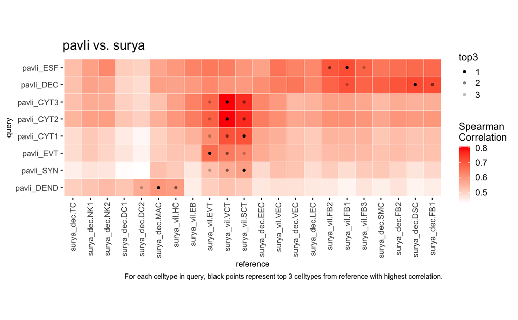

```r
pavli.vs.surya <- celltypeCorPlot(expdat = vsp, query = "pavli", reference = "surya")
cowplot::ggsave2(pavli.vs.surya, filename = "../results/01_reference-atlas/corr-plot_pavli-vs-surya.pdf",
                 device = "pdf", width = 6, height = 4, units = "in")
print(pavli.vs.surya)
```

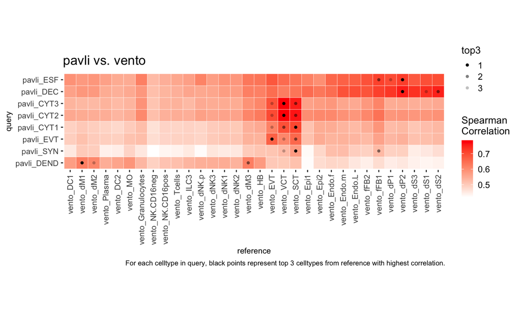

```r
pavli.vs.vento <- celltypeCorPlot(expdat = vsp, query = "pavli", reference = "vento")
cowplot::ggsave2(pavli.vs.vento, filename = "../results/01_reference-atlas/corr-plot_pavli-vs-vento.pdf",
                 device = "pdf", width = 7, height = 4, units = "in")
print(pavli.vs.vento)
```

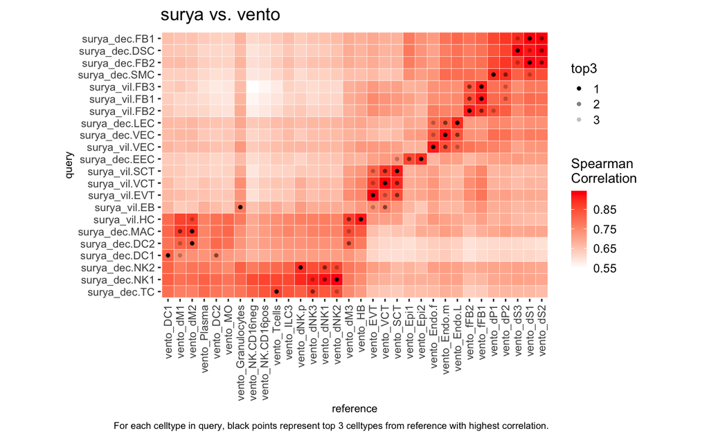

```r
surya.vs.vento <- celltypeCorPlot(expdat = vsp, query = "surya", reference = "vento")
cowplot::ggsave2(surya.vs.vento, filename = "../results/01_reference-atlas/corr-plot_surya-vs-vento.pdf",
                 device = "pdf", width = 7, height = 6, units = "in")
print(surya.vs.vento)
```

# 6 References

Pavličev, M., G. P. Wagner, A. R. Chavan, K. Owens, J. Maziarz, C. Dunn-Fletcher, S. G. Kallapur, L. Muglia, and H. Jones. 2017. “Single-Cell Transcriptomics of the Human Placenta: Inferring the Cell Communication Network of the Maternal-Fetal Interface.” *Genome Research*. https://doi.org/10.1101/gr.207597.116.

Suryawanshi, H., P. Morozov, A. Straus, N. Sahasrabudhe, K. E. A. Max, A. Garzia, M. Kustagi, T. Tuschl, and Z. Williams. 2018. “A Single-Cell Survey of the Human First-Trimester Placenta and Decidua.” *Science Advances* 4 (10): eaau4788. https://doi.org/10.1126/sciadv.aau4788.

Vento-Tormo, R., M. Efremova, R. A. Botting, M. Y. Turco, M. Vento-Tormo, K. B. Meyer, J-E. Park, et al. 2018. “Single-Cell Reconstruction of the Early Maternal–Fetal Interface in Humans.” *Nature* 563 (7731): 347–53. https://doi.org/10.1038/s41586-018-0698-6.